# Project

T Makuwerere , Mark Asamoah , Sandiles N

5/29/2022

## 0.1 Importing the dataset

```r
df <- read.csv2('https://raw.githubusercontent.com/mcasky16/RR_Final_Project/main/student_feedback.csv', sep = ',')
```

COLUMN NAMES names(df) ## [1] “X”  
## [2] “Student.ID”  
## [3] “Well.versed.with.the.subject”  
## [4] “Explains.concepts.in.an.understandable.way”  
## [5] “Use.of.presentations”  
## [6] “Degree.of.difficulty.of.assignments”  
## [7] “Solves.doubts.willingly”  
## [8] “Structuring.of.the.course”  
## [9] “Provides.support.for.students.going.above.and.beyond” ## [10] “Course.recommendation.based.on.relevance”

POTENTIAL QUESTIONS TO BE ANSWERED How is “course recommendation based on relevance distributed” as density plot?

Average use of presentation

CORRELATION between solves doubt AND explain concept in an understandable way

Bar chart student well versed with the topic

on the scale to one to 10 how much difficult assignment is 6- scale and 7-scale

Bar chart rating for teacher that Solves doubt willingly

REMOVING MISSING VALUES TO CLEAN THE DATA AND AVOID ERRORS df_nona implies df with no null values

```r
df_nona = df%>%
drop_na()
```

How is “course recommendation based on relevance distributed” as density plot?

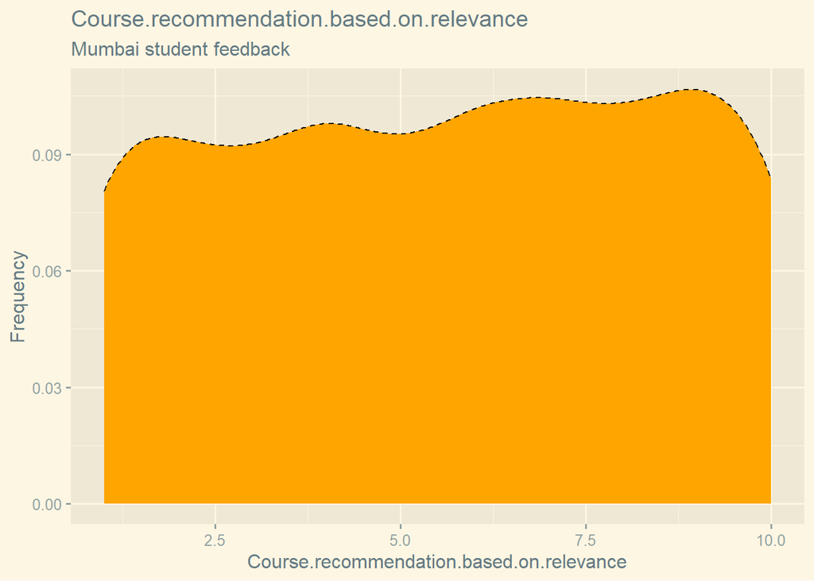

## Average use of presentation

```r
df_nona %>%
summarize(average_use_ofpresentation= round(mean(Use.of.presentations)))
```

```
##   average_use_ofpresentation
## 1                          6
```

on the scale of 1-10 average ratimg that student feel that they will use presentation for topic is 6

on the scale to one to 10 ho much difficult assignment is 6- scale and 7-scale

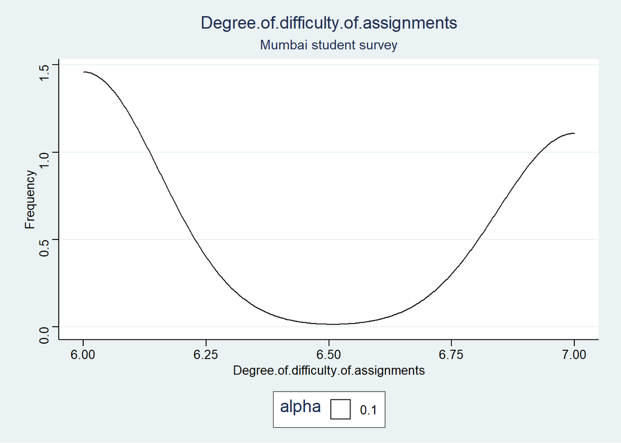

```r
df_nona %>%
  filter(Degree.of.difficulty.of.assignments %in% c('6', '7'))%>%
  ggplot() +
  geom_density(aes(x = Degree.of.difficulty.of.assignments , fill = Degree.of.difficulty.of.assignments , alpha = 0.1))+
  labs(title = 'Degree.of.difficulty.of.assignments',
       subtitle= 'Mumbai student survey' , x= 'Degree.of.difficulty.of.assignments',y= 'Frequency') +
  ggthemes::theme_stata()
```